# Optimal Treatment Analysis

## Outcome Variable

**Outcome Variable:** haz

## Predictor Variables

**Intervention Variable:** perdiar24

**Adjustment Set:**

- arm
- sex
- meducyrs
- hhwealth_quart
- hfoodsec
- hdlvry
- W_birthwt
- W_birthlen
- W_nrooms
- month
- brthmon
- impfloor
- impsan
- safeh20
- delta_meducyrs
- delta_hhwealth_quart
- delta_hfoodsec
- delta_hdlvry
- delta_W_birthwt
- delta_W_birthlen
- delta_W_nrooms
- delta_month
- delta_brthmon
- delta_impfloor
- delta_impsan
- delta_safeh20

## Stratifying Variables

The analysis was stratified on these variable(s):

- agecat
- studyid
- country

## Data Summary

| agecat | studyid | country | perdiar24 | n_cell | n |
| --- | --- | --- | --- | --- | --- |
| Birth | ki0047075b-MAL-ED | BANGLADESH | (0%, 5%] | 146 | 257 |
| Birth | ki0047075b-MAL-ED | BANGLADESH | >5% | 89 | 257 |
| Birth | ki0047075b-MAL-ED | BANGLADESH | 0% | 22 | 257 |
| Birth | ki0047075b-MAL-ED | BRAZIL | (0%, 5%] | 81 | 191 |
| Birth | ki0047075b-MAL-ED | BRAZIL | >5% | 2 | 191 |
| Birth | ki0047075b-MAL-ED | BRAZIL | 0% | 108 | 191 |
| Birth | ki0047075b-MAL-ED | INDIA | (0%, 5%] | 156 | 206 |
| Birth | ki0047075b-MAL-ED | INDIA | >5% | 38 | 206 |
| Birth | ki0047075b-MAL-ED | INDIA | 0% | 12 | 206 |
| Birth | ki0047075b-MAL-ED | NEPAL | (0%, 5%] | 103 | 173 |
| Birth | ki0047075b-MAL-ED | NEPAL | >5% | 56 | 173 |
| Birth | ki0047075b-MAL-ED | NEPAL | 0% | 14 | 173 |
| Birth | ki0047075b-MAL-ED | PERU | (0%, 5%] | 109 | 287 |
| Birth | ki0047075b-MAL-ED | PERU | >5% | 151 | 287 |
| Birth | ki0047075b-MAL-ED | PERU | 0% | 27 | 287 |
| Birth | ki0047075b-MAL-ED | SOUTH AFRICA | (0%, 5%] | 154 | 252 |
| Birth | ki0047075b-MAL-ED | SOUTH AFRICA | >5% | 3 | 252 |
| Birth | ki0047075b-MAL-ED | SOUTH AFRICA | 0% | 95 | 252 |
| Birth | ki0047075b-MAL-ED | TANZANIA, UNITED REPUBLIC OF | (0%, 5%] | 90 | 123 |
| Birth | ki0047075b-MAL-ED | TANZANIA, UNITED REPUBLIC OF | >5% | 25 | 123 |
| Birth | ki0047075b-MAL-ED | TANZANIA, UNITED REPUBLIC OF | 0% | 8 | 123 |
| Birth | ki1000109-EE | PAKISTAN | (0%, 5%] | 2 | 2 |
| Birth | ki1000109-EE | PAKISTAN | >5% | 0 | 2 |
| Birth | ki1000109-EE | PAKISTAN | 0% | 0 | 2 |
| Birth | ki1000109-ResPak | PAKISTAN | (0%, 5%] | 2 | 6 |
| Birth | ki1000109-ResPak | PAKISTAN | >5% | 4 | 6 |
| Birth | ki1000109-ResPak | PAKISTAN | 0% | 0 | 6 |
| Birth | ki1017093-NIH-Birth | BANGLADESH | (0%, 5%] | 8 | 26 |
| Birth | ki1017093-NIH-Birth | BANGLADESH | >5% | 14 | 26 |
| Birth | ki1017093-NIH-Birth | BANGLADESH | 0% | 4 | 26 |

[output cut: 123 more lines]

The following strata were considered:

- agecat: 24 months, studyid: ki0047075b-MAL-ED, country: BANGLADESH
- agecat: 24 months, studyid: ki0047075b-MAL-ED, country: BRAZIL
- agecat: 24 months, studyid: ki0047075b-MAL-ED, country: INDIA
- agecat: 24 months, studyid: ki0047075b-MAL-ED, country: NEPAL
- agecat: 24 months, studyid: ki0047075b-MAL-ED, country: PERU
- agecat: 24 months, studyid: ki0047075b-MAL-ED, country: SOUTH AFRICA
- agecat: 24 months, studyid: ki0047075b-MAL-ED, country: TANZANIA, UNITED REPUBLIC OF
- agecat: 24 months, studyid: ki1017093-NIH-Birth, country: BANGLADESH
- agecat: 24 months, studyid: ki1017093b-PROVIDE, country: BANGLADESH
- agecat: 24 months, studyid: ki1017093c-NIH-Crypto, country: BANGLADESH
- agecat: 24 months, studyid: ki1114097-CMIN, country: BANGLADESH
- agecat: 24 months, studyid: ki1114097-CMIN, country: GUINEA-BISSAU
- agecat: 24 months, studyid: ki1114097-CMIN, country: PERU
- agecat: 24 months, studyid: ki1114097-CONTENT, country: PERU
- agecat: 24 months, studyid: kiGH5241-JiVitA-4, country: BANGLADESH
- agecat: 6 months, studyid: ki0047075b-MAL-ED, country: BANGLADESH
- agecat: 6 months, studyid: ki0047075b-MAL-ED, country: BRAZIL
- agecat: 6 months, studyid: ki0047075b-MAL-ED, country: INDIA
- agecat: 6 months, studyid: ki0047075b-MAL-ED, country: NEPAL
- agecat: 6 months, studyid: ki0047075b-MAL-ED, country: PERU
- agecat: 6 months, studyid: ki0047075b-MAL-ED, country: SOUTH AFRICA
- agecat: 6 months, studyid: ki0047075b-MAL-ED, country: TANZANIA, UNITED REPUBLIC OF
- agecat: 6 months, studyid: ki1000109-EE, country: PAKISTAN
- agecat: 6 months, studyid: ki1000109-ResPak, country: PAKISTAN
- agecat: 6 months, studyid: ki1000304b-SAS-FoodSuppl, country: INDIA
- agecat: 6 months, studyid: ki1017093-NIH-Birth, country: BANGLADESH
- agecat: 6 months, studyid: ki1017093b-PROVIDE, country: BANGLADESH
- agecat: 6 months, studyid: ki1017093c-NIH-Crypto, country: BANGLADESH
- agecat: 6 months, studyid: ki1112895-Guatemala BSC, country: GUATEMALA
- agecat: 6 months, studyid: ki1114097-CMIN, country: BANGLADESH
- agecat: 6 months, studyid: ki1114097-CMIN, country: BRAZIL
- agecat: 6 months, studyid: ki1114097-CMIN, country: GUINEA-BISSAU
- agecat: 6 months, studyid: ki1114097-CMIN, country: PERU
- agecat: 6 months, studyid: ki1114097-CONTENT, country: PERU
- agecat: 6 months, studyid: kiGH5241-JiVitA-4, country: BANGLADESH
- agecat: Birth, studyid: ki0047075b-MAL-ED, country: BANGLADESH
- agecat: Birth, studyid: ki0047075b-MAL-ED, country: BRAZIL
- agecat: Birth, studyid: ki0047075b-MAL-ED, country: INDIA
- agecat: Birth, studyid: ki0047075b-MAL-ED, country: NEPAL
- agecat: Birth, studyid: ki0047075b-MAL-ED, country: PERU
- agecat: Birth, studyid: ki0047075b-MAL-ED, country: SOUTH AFRICA
- agecat: Birth, studyid: ki0047075b-MAL-ED, country: TANZANIA, UNITED REPUBLIC OF
- agecat: Birth, studyid: ki1000109-EE, country: PAKISTAN
- agecat: Birth, studyid: ki1000109-ResPak, country: PAKISTAN
- agecat: Birth, studyid: ki1017093-NIH-Birth, country: BANGLADESH
- agecat: Birth, studyid: ki1017093c-NIH-Crypto, country: BANGLADESH
- agecat: Birth, studyid: ki1114097-CMIN, country: BANGLADESH
- agecat: Birth, studyid: ki1114097-CMIN, country: BRAZIL
- agecat: Birth, studyid: ki1114097-CMIN, country: PERU
- agecat: Birth, studyid: ki1114097-CONTENT, country: PERU
- agecat: Birth, studyid: kiGH5241-JiVitA-4, country: BANGLADESH

### Dropped Strata

Some strata were dropped due to rare outcomes:

- agecat: Birth, studyid: ki0047075b-MAL-ED, country: BRAZIL
- agecat: Birth, studyid: ki0047075b-MAL-ED, country: SOUTH AFRICA
- agecat: Birth, studyid: ki1000109-EE, country: PAKISTAN
- agecat: Birth, studyid: ki1000109-ResPak, country: PAKISTAN
- agecat: Birth, studyid: ki1017093-NIH-Birth, country: BANGLADESH
- agecat: Birth, studyid: ki1114097-CMIN, country: BANGLADESH
- agecat: Birth, studyid: ki1114097-CMIN, country: BRAZIL
- agecat: Birth, studyid: ki1114097-CMIN, country: PERU
- agecat: Birth, studyid: ki1114097-CONTENT, country: PERU
- agecat: 6 months, studyid: ki0047075b-MAL-ED, country: BRAZIL
- agecat: 6 months, studyid: ki0047075b-MAL-ED, country: INDIA
- agecat: 6 months, studyid: ki0047075b-MAL-ED, country: SOUTH AFRICA
- agecat: 6 months, studyid: ki1114097-CMIN, country: BANGLADESH
- agecat: 6 months, studyid: ki1114097-CMIN, country: BRAZIL
- agecat: 24 months, studyid: ki0047075b-MAL-ED, country: BRAZIL
- agecat: 24 months, studyid: ki0047075b-MAL-ED, country: INDIA
- agecat: 24 months, studyid: ki0047075b-MAL-ED, country: PERU
- agecat: 24 months, studyid: ki0047075b-MAL-ED, country: SOUTH AFRICA
- agecat: 24 months, studyid: ki1114097-CMIN, country: BANGLADESH
- agecat: 24 months, studyid: ki1114097-CONTENT, country: PERU

## Methods Detail

We’re interested in the causal parameters $E[Y_a]$ for all values of $a \in \mathcal{A}$. These parameters represent the mean outcome if, possibly contrary to fact, we intervened to set all units to have $A=a$. Under the randomization and positivity assumptions, these are identified by the statistical parameters $\psi_a=E_W[E_{Y|A,W}(Y|A=a,W)]$. In addition, we’re interested in the mean of $Y$, $E[Y]$ under no intervention (the observed mean). We will estimate these parameters by using SuperLearner to fit the relevant likelihood factors – $E_{Y|A,W}(Y|A=a,W)$ and $p(A=a|W)$, and then updating our likelihood fit using a joint TMLE.

For unadjusted analyses ($W=\{\}$), initial likelihoods were estimated using Lrnr_glm to estimate the simple $E(Y|A)$ and Lrnr_mean to estimate $p(A)$. For adjusted analyses, a small library containing Lrnr_glmnet, Lrnr_xgboost, and Lrnr_mean was used.

Having estimated these parameters, we will then use the delta method to estimate relative risks and attributable risks relative to a prespecified baseline level of $A$.

# Results Detail

## Results Plots

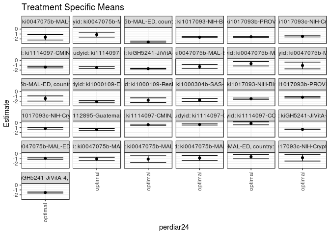

## Results Table

### Parameter: TSM

| agecat | studyid | country | intervention_level | baseline_level | estimate | ci_lower | ci_upper |
| --- | --- | --- | --- | --- | --- | --- | --- |
| Birth | ki0047075b-MAL-ED | BANGLADESH | optimal | observed | -0.9403299 | -1.0882210 | -0.7924389 |
| Birth | ki0047075b-MAL-ED | INDIA | optimal | observed | -1.0395456 | -1.3878095 | -0.6912817 |
| Birth | ki0047075b-MAL-ED | NEPAL | optimal | observed | -1.0656772 | -1.7469177 | -0.3844367 |
| Birth | ki0047075b-MAL-ED | PERU | optimal | observed | -0.8461206 | -1.3698279 | -0.3224134 |
| Birth | ki0047075b-MAL-ED | TANZANIA, UNITED REPUBLIC OF | optimal | observed | -0.5801283 | -1.0084417 | -0.1518149 |
| Birth | ki1017093c-NIH-Crypto | BANGLADESH | optimal | observed | -0.7876138 | -1.4745308 | -0.1006969 |
| Birth | kiGH5241-JiVitA-4 | BANGLADESH | optimal | observed | -1.5343285 | -1.6476178 | -1.4210392 |
| 6 months | ki0047075b-MAL-ED | BANGLADESH | optimal | observed | -1.2846949 | -1.7082373 | -0.8611526 |
| 6 months | ki0047075b-MAL-ED | NEPAL | optimal | observed | -0.6812283 | -1.1450634 | -0.2173933 |
| 6 months | ki0047075b-MAL-ED | PERU | optimal | observed | -1.0571713 | -1.7462418 | -0.3681009 |
| 6 months | ki0047075b-MAL-ED | TANZANIA, UNITED REPUBLIC OF | optimal | observed | -1.4315837 | -1.9640816 | -0.8990857 |
| 6 months | ki1000109-EE | PAKISTAN | optimal | observed | -2.0841086 | -2.3031997 | -1.8650175 |
| 6 months | ki1000109-ResPak | PAKISTAN | optimal | observed | -1.7799925 | -2.2593108 | -1.3006741 |
| 6 months | ki1000304b-SAS-FoodSuppl | INDIA | optimal | observed | -1.7308186 | -2.0341191 | -1.4275180 |
| 6 months | ki1017093-NIH-Birth | BANGLADESH | optimal | observed | -1.4727904 | -1.6010696 | -1.3445113 |
| 6 months | ki1017093b-PROVIDE | BANGLADESH | optimal | observed | -1.1857108 | -1.3192145 | -1.0522072 |
| 6 months | ki1017093c-NIH-Crypto | BANGLADESH | optimal | observed | -1.1740069 | -1.3243029 | -1.0237110 |
| 6 months | ki1112895-Guatemala BSC | GUATEMALA | optimal | observed | -1.4118510 | -1.6386280 | -1.1850739 |
| 6 months | ki1114097-CMIN | GUINEA-BISSAU | optimal | observed | -0.4192634 | -0.5308508 | -0.3076759 |
| 6 months | ki1114097-CMIN | PERU | optimal | observed | -0.3709558 | -0.4938707 | -0.2480408 |
| 6 months | ki1114097-CONTENT | PERU | optimal | observed | -0.1405888 | -0.4498178 | 0.1686402 |
| 6 months | kiGH5241-JiVitA-4 | BANGLADESH | optimal | observed | -1.3732204 | -1.4432396 | -1.3032011 |
| 24 months | ki0047075b-MAL-ED | BANGLADESH | optimal | observed | -1.6576436 | -2.2248217 | -1.0904655 |
| 24 months | ki0047075b-MAL-ED | NEPAL | optimal | observed | -1.1336191 | -1.6304164 | -0.6368218 |
| 24 months | ki0047075b-MAL-ED | TANZANIA, UNITED REPUBLIC OF | optimal | observed | -2.6276374 | -2.8047531 | -2.4505218 |
| 24 months | ki1017093-NIH-Birth | BANGLADESH | optimal | observed | -1.6447595 | -1.7502937 | -1.5392253 |
| 24 months | ki1017093b-PROVIDE | BANGLADESH | optimal | observed | -1.5687227 | -1.6668414 | -1.4706041 |
| 24 months | ki1017093c-NIH-Crypto | BANGLADESH | optimal | observed | -1.4826233 | -1.6036034 | -1.3616431 |
| 24 months | ki1114097-CMIN | GUINEA-BISSAU | optimal | observed | -1.3826021 | -1.5454504 | -1.2197539 |
| 24 months | ki1114097-CMIN | PERU | optimal | observed | -1.4856501 | -1.6865418 | -1.2847584 |
| 24 months | kiGH5241-JiVitA-4 | BANGLADESH | optimal | observed | -1.7090272 | -1.7774265 | -1.6406279 |

### Parameter: E(Y)

| agecat | studyid | country | intervention_level | baseline_level | estimate | ci_lower | ci_upper |
| --- | --- | --- | --- | --- | --- | --- | --- |
| Birth | ki0047075b-MAL-ED | BANGLADESH | observed | observed | -1.0843969 | -1.2100768 | -0.9587169 |
| Birth | ki0047075b-MAL-ED | INDIA | observed | observed | -1.0106311 | -1.1499962 | -0.8712660 |
| Birth | ki0047075b-MAL-ED | NEPAL | observed | observed | -0.7089017 | -0.8656064 | -0.5521971 |
| Birth | ki0047075b-MAL-ED | PERU | observed | observed | -0.9322300 | -1.0461262 | -0.8183337 |
| Birth | ki0047075b-MAL-ED | TANZANIA, UNITED REPUBLIC OF | observed | observed | -0.9338211 | -1.1465079 | -0.7211344 |
| Birth | ki1017093c-NIH-Crypto | BANGLADESH | observed | observed | -1.1100000 | -1.5086894 | -0.7113106 |
| Birth | kiGH5241-JiVitA-4 | BANGLADESH | observed | observed | -1.4976642 | -1.5817349 | -1.4135935 |
| 6 months | ki0047075b-MAL-ED | BANGLADESH | observed | observed | -1.2056777 | -1.3231497 | -1.0882058 |
| 6 months | ki0047075b-MAL-ED | NEPAL | observed | observed | -0.5610593 | -0.6737915 | -0.4483272 |
| 6 months | ki0047075b-MAL-ED | PERU | observed | observed | -1.3268010 | -1.4351217 | -1.2184802 |
| 6 months | ki0047075b-MAL-ED | TANZANIA, UNITED REPUBLIC OF | observed | observed | -1.3601215 | -1.4821830 | -1.2380600 |
| 6 months | ki1000109-EE | PAKISTAN | observed | observed | -2.2004704 | -2.3234073 | -2.0775336 |
| 6 months | ki1000109-ResPak | PAKISTAN | observed | observed | -1.4029220 | -1.6085859 | -1.1972581 |
| 6 months | ki1000304b-SAS-FoodSuppl | INDIA | observed | observed | -1.8986842 | -2.0118892 | -1.7854792 |
| 6 months | ki1017093-NIH-Birth | BANGLADESH | observed | observed | -1.4073821 | -1.4960598 | -1.3187043 |
| 6 months | ki1017093b-PROVIDE | BANGLADESH | observed | observed | -1.0871041 | -1.1635539 | -1.0106543 |
| 6 months | ki1017093c-NIH-Crypto | BANGLADESH | observed | observed | -1.1986783 | -1.2700937 | -1.1272630 |
| 6 months | ki1112895-Guatemala BSC | GUATEMALA | observed | observed | -1.5619008 | -1.6727702 | -1.4510313 |
| 6 months | ki1114097-CMIN | GUINEA-BISSAU | observed | observed | -0.6003317 | -0.6767125 | -0.5239510 |
| 6 months | ki1114097-CMIN | PERU | observed | observed | -0.5132548 | -0.5926717 | -0.4338380 |
| 6 months | ki1114097-CONTENT | PERU | observed | observed | -0.3139217 | -0.4868486 | -0.1409948 |
| 6 months | kiGH5241-JiVitA-4 | BANGLADESH | observed | observed | -1.3447940 | -1.3820261 | -1.3075620 |
| 24 months | ki0047075b-MAL-ED | BANGLADESH | observed | observed | -1.9431132 | -2.0691678 | -1.8170586 |
| 24 months | ki0047075b-MAL-ED | NEPAL | observed | observed | -1.2752193 | -1.3954783 | -1.1549603 |
| 24 months | ki0047075b-MAL-ED | TANZANIA, UNITED REPUBLIC OF | observed | observed | -2.6058879 | -2.7403043 | -2.4714714 |
| 24 months | ki1017093-NIH-Birth | BANGLADESH | observed | observed | -2.1807945 | -2.2835902 | -2.0779987 |
| 24 months | ki1017093b-PROVIDE | BANGLADESH | observed | observed | -1.5861179 | -1.6693668 | -1.5028689 |
| 24 months | ki1017093c-NIH-Crypto | BANGLADESH | observed | observed | -1.4295331 | -1.5127726 | -1.3462935 |
| 24 months | ki1114097-CMIN | GUINEA-BISSAU | observed | observed | -1.5996561 | -1.6995642 | -1.4997481 |
| 24 months | ki1114097-CMIN | PERU | observed | observed | -1.5759624 | -1.6729826 | -1.4789423 |
| 24 months | kiGH5241-JiVitA-4 | BANGLADESH | observed | observed | -1.7582681 | -1.7937283 | -1.7228079 |

### Parameter: PAR

| agecat | studyid | country | intervention_level | baseline_level | estimate | ci_lower | ci_upper |
| --- | --- | --- | --- | --- | --- | --- | --- |
| Birth | ki0047075b-MAL-ED | BANGLADESH | optimal | observed | -0.1440670 | -0.2695980 | -0.0185360 |
| Birth | ki0047075b-MAL-ED | INDIA | optimal | observed | 0.0289145 | -0.3028698 | 0.3606988 |
| Birth | ki0047075b-MAL-ED | NEPAL | optimal | observed | 0.3567755 | -0.2707270 | 0.9842779 |
| Birth | ki0047075b-MAL-ED | PERU | optimal | observed | -0.0861093 | -0.5783253 | 0.4061066 |
| Birth | ki0047075b-MAL-ED | TANZANIA, UNITED REPUBLIC OF | optimal | observed | -0.3536928 | -0.7565219 | 0.0491363 |
| Birth | ki1017093c-NIH-Crypto | BANGLADESH | optimal | observed | -0.3223862 | -0.8737785 | 0.2290062 |
| Birth | kiGH5241-JiVitA-4 | BANGLADESH | optimal | observed | 0.0366643 | -0.0345740 | 0.1079026 |
| 6 months | ki0047075b-MAL-ED | BANGLADESH | optimal | observed | 0.0790172 | -0.3493634 | 0.5073978 |
| 6 months | ki0047075b-MAL-ED | NEPAL | optimal | observed | 0.1201690 | -0.3259648 | 0.5663029 |
| 6 months | ki0047075b-MAL-ED | PERU | optimal | observed | -0.2696296 | -0.9511335 | 0.4118742 |
| 6 months | ki0047075b-MAL-ED | TANZANIA, UNITED REPUBLIC OF | optimal | observed | 0.0714622 | -0.4381748 | 0.5810992 |
| 6 months | ki1000109-EE | PAKISTAN | optimal | observed | -0.1163618 | -0.3298504 | 0.0971268 |
| 6 months | ki1000109-ResPak | PAKISTAN | optimal | observed | 0.3770705 | -0.0930431 | 0.8471841 |
| 6 months | ki1000304b-SAS-FoodSuppl | INDIA | optimal | observed | -0.1678657 | -0.4572690 | 0.1215377 |
| 6 months | ki1017093-NIH-Birth | BANGLADESH | optimal | observed | 0.0654084 | -0.0309659 | 0.1617827 |
| 6 months | ki1017093b-PROVIDE | BANGLADESH | optimal | observed | 0.0986068 | -0.0022254 | 0.1994389 |
| 6 months | ki1017093c-NIH-Crypto | BANGLADESH | optimal | observed | -0.0246714 | -0.1564513 | 0.1071086 |
| 6 months | ki1112895-Guatemala BSC | GUATEMALA | optimal | observed | -0.1500498 | -0.3549313 | 0.0548317 |
| 6 months | ki1114097-CMIN | GUINEA-BISSAU | optimal | observed | -0.1810684 | -0.2726545 | -0.0894822 |
| 6 months | ki1114097-CMIN | PERU | optimal | observed | -0.1422991 | -0.2279614 | -0.0566367 |
| 6 months | ki1114097-CONTENT | PERU | optimal | observed | -0.1733329 | -0.4339526 | 0.0872868 |
| 6 months | kiGH5241-JiVitA-4 | BANGLADESH | optimal | observed | 0.0284263 | -0.0247645 | 0.0816172 |
| 24 months | ki0047075b-MAL-ED | BANGLADESH | optimal | observed | -0.2854696 | -0.8527527 | 0.2818134 |
| 24 months | ki0047075b-MAL-ED | NEPAL | optimal | observed | -0.1416002 | -0.6322336 | 0.3490333 |
| 24 months | ki0047075b-MAL-ED | TANZANIA, UNITED REPUBLIC OF | optimal | observed | 0.0217496 | -0.0893126 | 0.1328118 |
| 24 months | ki1017093-NIH-Birth | BANGLADESH | optimal | observed | -0.5360350 | -0.6817386 | -0.3903313 |
| 24 months | ki1017093b-PROVIDE | BANGLADESH | optimal | observed | -0.0173951 | -0.0760032 | 0.0412130 |
| 24 months | ki1017093c-NIH-Crypto | BANGLADESH | optimal | observed | 0.0530902 | -0.0434101 | 0.1495905 |
| 24 months | ki1114097-CMIN | GUINEA-BISSAU | optimal | observed | -0.2170540 | -0.3556730 | -0.0784350 |
| 24 months | ki1114097-CMIN | PERU | optimal | observed | -0.0903123 | -0.2607979 | 0.0801732 |
| 24 months | kiGH5241-JiVitA-4 | BANGLADESH | optimal | observed | -0.0492409 | -0.1061355 | 0.0076537 |